# Project 1: SAT & ACT Analysis

#### Plot and interpret boxplots

For each numeric variable in the dataframe create a boxplot using Seaborn. Boxplots demonstrate central tendency and spread in variables. In a certain sense, these are somewhat redundant with histograms, but you may be better able to identify clear outliers or differences in IQR, etc.

Multiple values can be plotted to a single boxplot as long as they are of the same relative scale (meaning they have similar min/max values).

Each boxplot should:

- Only include variables of a similar scale
- Have clear labels for each variable
- Have appropriate titles and labels

```python
boxplot_partn = ["participation_s17", "participation_s18", "participation_a17", "participation_a18"]
boxplot_ACT17_ACT18 = ["eng_a17", "eng_a18", "math_a17", "math_a18", "readg_a17", "readg_a18", "science_a17",
                       "science_a18"
                       ]
boxplot_ACT17_ACT18_comp = ["composite_a17", "composite_a18"
                            ]
boxplot_SAT17_SAT18_total = ["total_s17", "total_s18"
                             ]
boxplot_SAT17_SAT18 = ["math_s17", "math_s18", "erw_s17", "erw_s18"
                       ]
```

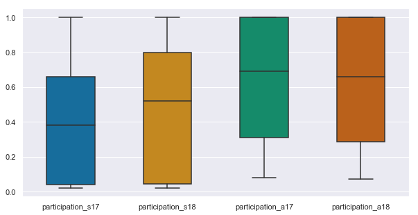

```python
fig, ax = plt.subplots(nrows=1, ncols=1, figsize=(10, 5))
sns.boxplot(data=final[boxplot_partn], width=0.5, palette="colorblind")
plt.show()
```

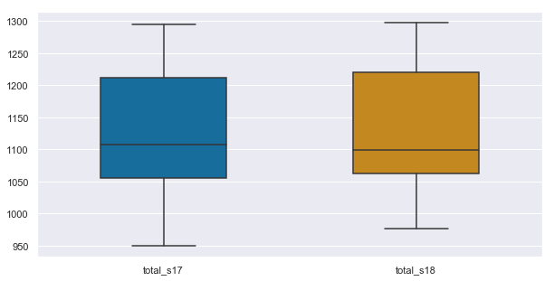

```python
fig, ax = plt.subplots(nrows=1, ncols=1, figsize=(10, 5))
sns.boxplot(data=final[boxplot_SAT17_SAT18_total], width=0.5, palette="colorblind")
plt.show()
```

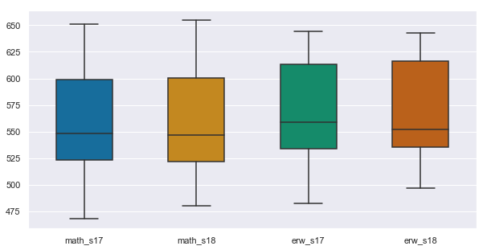

```python
fig, ax = plt.subplots(nrows=1, ncols=1, figsize=(10, 5))
sns.boxplot(data=final[boxplot_SAT17_SAT18], width=0.5, palette="colorblind")
plt.show()
```

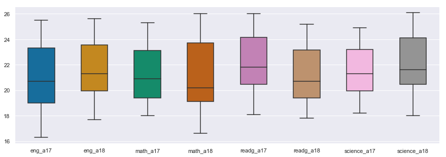

```python
fig, ax = plt.subplots(nrows=1, ncols=1, figsize=(15, 5))
sns.boxplot(data=final[boxplot_ACT17_ACT18], width=0.5, palette="colorblind")
plt.show()
```

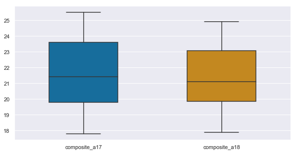

```python
fig, ax = plt.subplots(nrows=1, ncols=1, figsize=(10, 5))
sns.boxplot(data=final[boxplot_ACT17_ACT18_comp], width=0.5, palette="colorblind")
plt.show()
```

#### Boxplot Observation Summary

Above, we observe the boxplot distributions of all features across tests and years. Attempted to plot across years for each test and subjects.

Observations:

- All features could not be plotted in one figure due to the differences in scale.
- Each figure was plotted with subjects of similar scales.
- Generally, boxplots are similar for each subjects across 2017 and 2018
- No outliers were observed.

#### Estimate Limits of Data

Suppose we only seek to understand the relationship between SAT and ACT participation rates in 2017.

##### Does it make sense to conduct statistical inference given these data specifically?

Why or why not?

*(think about granularity, aggregation, the relationships between populations size & rates...consider the actually populations these data describe in answering this question)*

## Conclusions and Recommendations

Based on your exploration of the data, what are you key takeaways and recommendations? Choose one state with a lower participation rate and provide a suggestion for how the College Board might increase participation amongst graduating seniors in this state. Are there additional data you desire that would better inform your investigations?